# Shiny App Pitch: Introduction to Bayesian Inference

J. Mark Shoun  
30 November 2016

### Bayesian Inference App

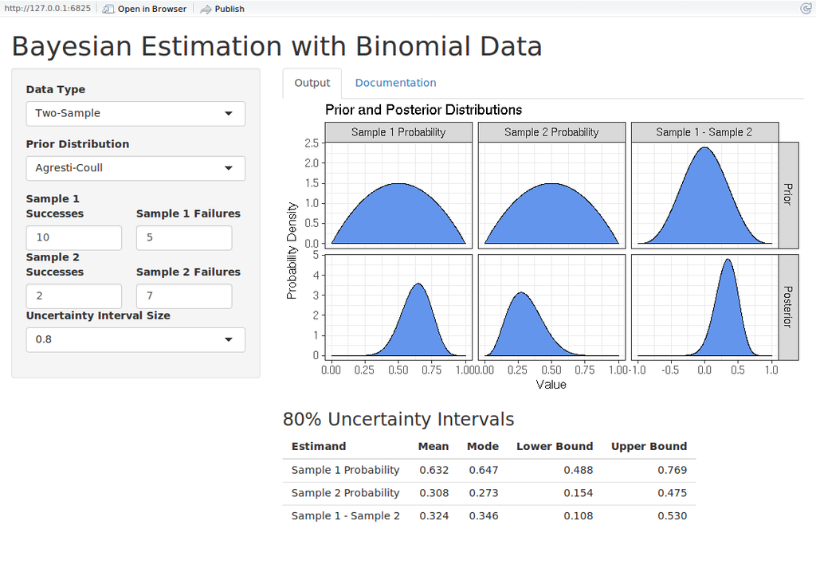

- [My application](https://jmshoun.shinyapps.io/data-product-final/) allows the user to experiment with Bayesian inference
- Presents simple but useful problem: one- and two-sample inference from binomial data
- Solves two problems with most intro statistics courses
- Source code for the application is [hosted here](https://github.com/jmshoun/data-product-final)

### Problem #1: Frequentist Binomial Inference is Hard

**Problem:**

- Exact one-sample confidence intervals are on discrete distribution
- Using normal approximation requires continuity correction
- Normal approximation doesn't work for small or extreme data
- Exact inference for two-sample data is complex.

**Solution:**

- Bayesian intervals are from continuous distributions
  - No approximation or discretization needed!
- Two-sample inference isn't much harder than one-sample

### Problem #2: Bayes' Theorem Is Given Short Shrift

**Problem:**

- Bayes' Theorem is a part of the standard curriculum, but…
- Only discrete examples are discussed (no continuous estimands)
- Choices of prior aren't discussed in detail
- Math for continuous Bayesian inference is considered intimidating

**Solution:**

- Show a simple but practical problem where the math is tractable
- Visualize the prior and posterior distributions to foster intuition
- Automatically take care of technical details

### Mathematical Details: How It Works

- The beta distribution is a *conjugate prior* for binomial/Bernoulli data
- If your prior distribution is beta, so is your posterior
- The beta distribution is included in R
- Easy example of how it works:
  - Find a 90% uncertainty interval
  - For 10 observed successes and 5 observed failures
  - Assuming a uniform prior on the probability scale

```r
interval.quantiles <- c(.05, .95)
successes <- 10
failures <- 5
qbeta(interval.quantiles, successes + 1, failures + 1)
```

```
[1] 0.4516529 0.8222341
```